# GLM

2023-03-09

```r
library(tidyverse)
```

```r
library(moderndive)
library(gapminder)
library(sjPlot)
library(stats)
library(jtools)
```

#Binary logistic regression with one numerical explanatory variable

```r
evals.gender <- evals %>%
                  select(gender, age)
evals.gender
```

| gender | age |
| --- | --- |
| female | 36 |
| female | 36 |
| female | 36 |
| female | 36 |
| male | 59 |
| male | 59 |
| male | 59 |
| male | 51 |
| male | 51 |
| female | 40 |

[output cut: 453 more lines]

look at a boxplot of by to get an initial impression of the data

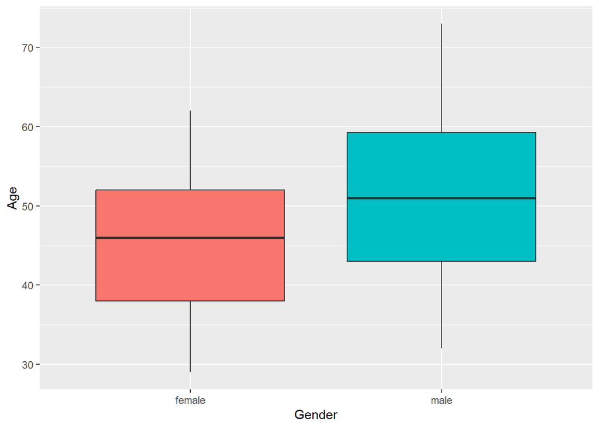

```r
ggplot(data = evals.gender, aes(x = gender, y = age, fill = gender)) +
  geom_boxplot() +
  labs(x = "Gender", y = "Age")+
  theme(legend.position = "none")
```

## Log-odds

The logistic regression model with **gender** as the response and **age** as the explanatory variable is given by:

```r
model <- glm(gender ~ age, data = evals.gender,
             family = binomial(link = "logit"))
model
```

```
##
## Call:  glm(formula = gender ~ age, family = binomial(link = "logit"),
##     data = evals.gender)
##
## Coefficients:
## (Intercept)          age
##    -2.69795      0.06296
##
## Degrees of Freedom: 462 Total (i.e. Null);  461 Residual
## Null Deviance:       630.3
## Residual Deviance: 591.4     AIC: 595.4
```

```r
model %>%
  summary()
```

```
##
## Call:
## glm(formula = gender ~ age, family = binomial(link = "logit"),
##     data = evals.gender)
##
## Deviance Residuals:
##     Min       1Q   Median       3Q      Max
## -1.7134  -1.1815   0.7238   1.0180   1.4778
##
## Coefficients:
##             Estimate Std. Error z value Pr(>|z|)
## (Intercept) -2.69795    0.51194  -5.270 1.36e-07 ***
## age          0.06296    0.01059   5.948 2.71e-09 ***
## ---
## Signif. codes:  0 '***' 0.001 '**' 0.01 '*' 0.05 '.' 0.1 ' ' 1
##
## (Dispersion parameter for binomial family taken to be 1)
##
##     Null deviance: 630.30  on 462  degrees of freedom
## Residual deviance: 591.41  on 461  degrees of freedom
## AIC: 595.41
##
## Number of Fisher Scoring iterations: 4
```

```r
#or
summ(model)
```

| Observations | 463 |
| --- | --- |
| Dependent variable | gender |
| Type | Generalized linear model |
| Family | binomial |
| Link | logit |

| χ²(1) | 38.89 |
| --- | --- |
| Pseudo-R² (Cragg-Uhler) | 0.11 |
| Pseudo-R² (McFadden) | 0.06 |
| AIC | 595.41 |
| BIC | 603.68 |

|  | Est. | S.E. | z val. | p |
| --- | --- | --- | --- | --- |
| (Intercept) | -2.70 | 0.51 | -5.27 | 0.00 |
| age | 0.06 | 0.01 | 5.95 | 0.00 |

Standard errors: MLE

*Baseline* in R being taken as the one which comes first alphabetically, in this model is **female**.

```r
levels(evals.gender$gender)
```

```
## [1] "female" "male"
```

extract the estimated coefficients:

```r
mod1coefs <- round(coef(model), 2)
mod1coefs
```

```
## (Intercept)         age
##       -2.70        0.06
```

$$\begin{align}
\ln\left(\frac{p}{1-p}\right) &= \alpha + \beta \cdot
\textrm{age} = -2.7 + 0.06 \cdot \textrm{age} \nonumber
\end{align}$$

The *log-odds* of the instructor being male increase by 0.06 for every one unit increase in. a 95% confidence interval for these log-odds:

```r
library(kableExtra)
confint(model) %>%
  kable()
```

|  | 2.5 % | 97.5 % |
| --- | --- | --- |
| (Intercept) | -3.7196499 | -1.7097067 |
| age | 0.0425879 | 0.0841436 |

```r
mod.coef.logodds <- model %>%
                      summary() %>%
                      coef()
mod.coef.logodds
```

```
##                Estimate Std. Error   z value     Pr(>|z|)
## (Intercept) -2.69794604 0.51193785 -5.270066 1.363751e-07
## age          0.06296472 0.01058518  5.948386 2.707998e-09
```

```r
#logodds.lower
age.logodds.lower <- mod.coef.logodds["age", "Estimate"] -
                      1.96 * mod.coef.logodds["age", "Std. Error"]
age.logodds.lower
```

```
## [1] 0.04221777
```

```r
#logodds.upper
age.logodds.upper <- mod.coef.logodds["age", "Estimate"] +
                      1.96 * mod.coef.logodds["age", "Std. Error"]
age.logodds.upper
```

```
## [1] 0.08371167
```

Hence the point estimate for the log-odds is 0.06, which has a corresponding 95% confidence interval of (0.04, 0.08),This can be displayed graphically :

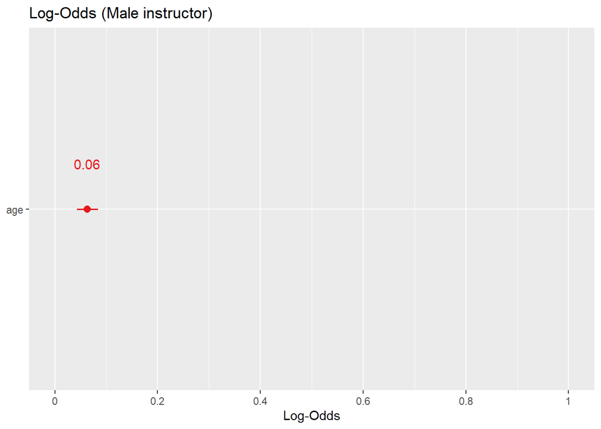

```r
#The log-odds of age for male instructors.
plot_model(model, show.values = TRUE, transform = NULL,
           title = "Log-Odds (Male instructor)", show.p = FALSE)
```

let’s add the estimates of the log-odds to our data set:

```r
evals.gender <- evals.gender %>%
                  mutate(logodds.male = predict(model))
evals.gender
```

| gender | age | logodds.male |
| --- | --- | --- |
| female | 36 | -0.431216046 |
| female | 36 | -0.431216046 |
| female | 36 | -0.431216046 |
| female | 36 | -0.431216046 |
| male | 59 | 1.016972561 |
| male | 59 | 1.016972561 |
| male | 59 | 1.016972561 |
| male | 51 | 0.513254785 |
| male | 51 | 0.513254785 |
| female | 40 | -0.179357158 |

[output cut: 453 more lines]

```r
evals.gender[evals.gender$age==29 ,3]
```

| logodds.male |
| --- |
| -0.8719691 |

## odds

odds scale as it is easier to interpret an odds-ratio as opposed to the log-odds-ratio.

```r
model %>%
 coef() %>%
  exp()
```

```
## (Intercept)         age
##  0.06734369  1.06498927
```

```r
age.odds.lower <- exp(age.logodds.lower)
age.odds.upper <- exp(age.logodds.upper)
age.odds.lower
```

```
## [1] 1.043122
```

```r
age.odds.upper
```

```
## [1] 1.087315
```

Hence the point estimate for the odds is 1.06, which has a corresponding 95% confidence interval of (1.04, 1.09). displayed graphically :

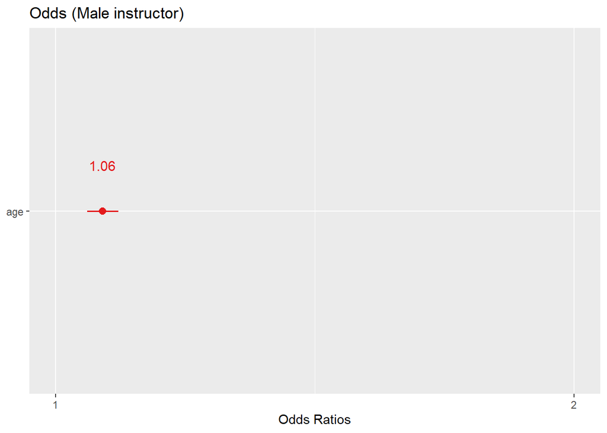

```r
plot_model(model, show.values = TRUE, axis.lim = c(1,1.5),
           title = "Odds (Male instructor)", show.p = FALSE)
```

```r
evals.gender <- evals.gender %>%
                  mutate(odds.male = exp(logodds.male))
evals.gender
```

| gender | age | logodds.male | odds.male |
| --- | --- | --- | --- |
| female | 36 | -0.431216046 | 0.6497185 |
| female | 36 | -0.431216046 | 0.6497185 |
| female | 36 | -0.431216046 | 0.6497185 |
| female | 36 | -0.431216046 | 0.6497185 |
| male | 59 | 1.016972561 | 2.7648118 |
| male | 59 | 1.016972561 | 2.7648118 |
| male | 59 | 1.016972561 | 2.7648118 |
| male | 51 | 0.513254785 | 1.6707202 |
| male | 51 | 0.513254785 | 1.6707202 |
| female | 40 | -0.179357158 | 0.8358073 |

[output cut: 453 more lines]

```r
evals.gender[evals.gender$age==56 ,4]
```

| odds.male |
| --- |
| 2.288916 |
| 2.288916 |
| 2.288916 |
| 2.288916 |
| 2.288916 |
| 2.288916 |
| 2.288916 |
| 2.288916 |

## Probabilities

```r
p.num <- exp(mod.coef.logodds["(Intercept)", "Estimate"] + mod.coef.logodds["age", "Estimate"] * 52)
p.denom <- 1 + p.num
p.num / p.denom
```

```
## [1] 0.6401971
```

or use **plogis()** function

```r
plogis(mod.coef.logodds["(Intercept)", "Estimate"] + mod.coef.logodds["age", "Estimate"] * 52)
```

```
## [1] 0.6401971
```

add the probabilities to our data:

```r
evals.gender <- evals.gender %>%
                  mutate(probs.male = fitted(model))
evals.gender
```

| gender | age | logodds.male | odds.male | probs.male |
| --- | --- | --- | --- | --- |
| female | 36 | -0.431216046 | 0.6497185 | 0.3938360 |
| female | 36 | -0.431216046 | 0.6497185 | 0.3938360 |
| female | 36 | -0.431216046 | 0.6497185 | 0.3938360 |
| female | 36 | -0.431216046 | 0.6497185 | 0.3938360 |
| male | 59 | 1.016972561 | 2.7648118 | 0.7343825 |
| male | 59 | 1.016972561 | 2.7648118 | 0.7343825 |
| male | 59 | 1.016972561 | 2.7648118 | 0.7343825 |
| male | 51 | 0.513254785 | 1.6707202 | 0.6255692 |
| male | 51 | 0.513254785 | 1.6707202 | 0.6255692 |
| female | 40 | -0.179357158 | 0.8358073 | 0.4552805 |

[output cut: 453 more lines]

```r
#estimated probabilities.
predict(model, type = "response")
```

[output not shown]

[output cut: 61 more lines]

[output not shown]

```r
#??????????
evals.gender[evals.gender$age==33 & evals.gender$gender=="female",5]
```

| probs.male |
| --- |
| 0.3497564 |
| 0.3497564 |
| 0.3497564 |
| 0.3497564 |
| 0.3497564 |
| 0.3497564 |
| 0.3497564 |
| 0.3497564 |
| 0.3497564 |
| 0.3497564 |

[output cut: 8 more lines]

```r
#??????????
```

plot the probability:

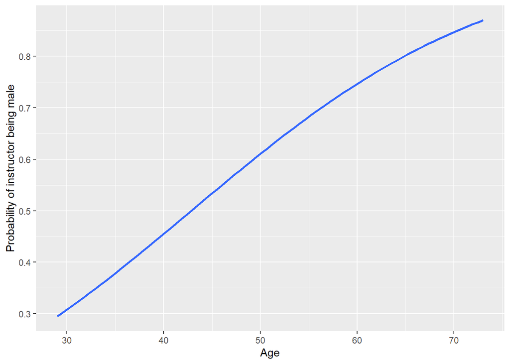

```r
ggplot(data = evals.gender, aes(x = age, y = probs.male)) +
  geom_smooth(method="glm",
              method.args = list(family="binomial"),
              se = FALSE) +
  labs(x = "Age", y = "Probability of instructor being male")
```

```
## Data were 'prettified'. Consider using `terms="age [all]"` to get smooth
##   plots.
```

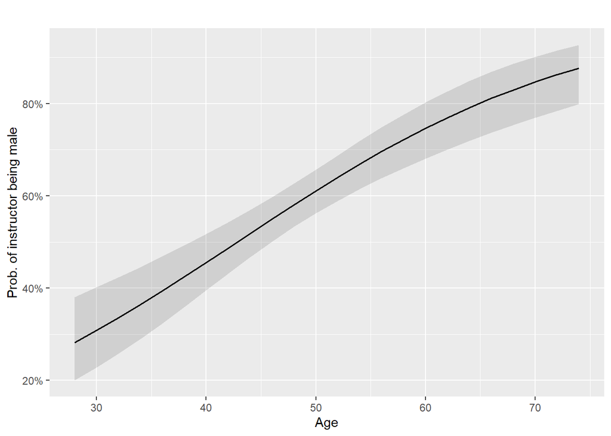

```r
plot_model(model, type = "pred", title = "",
            axis.title = c("Age", "Prob. of instructor being male"))
```

#Binary logistic regression with one categorical explanatory variable

the binary categorical variable **ethnicity** as our explanatory variable **gender** as the response

```r
evals.ethnic <- evals %>%
                  select(gender, ethnicity)
evals.ethnic
```

| gender | ethnicity |
| --- | --- |
| female | minority |
| female | minority |
| female | minority |
| female | minority |
| male | not minority |
| male | not minority |
| male | not minority |
| male | not minority |
| male | not minority |
| female | not minority |

[output cut: 453 more lines]

# summarise this data in a table format:

```r
library(janitor)
evals %>%
  tabyl(ethnicity, gender) %>%
  adorn_percentages() %>%
  adorn_pct_formatting() %>%
  adorn_ns() # To show original counts
```

|  | ethnicity | female | male |
| --- | --- | --- | --- |
| 1 | minority | 56.2% (36) | 43.8% (28) |
| 2 | not minority | 39.8% (159) | 60.2% (240) |

visualize the distribution using a barplot:

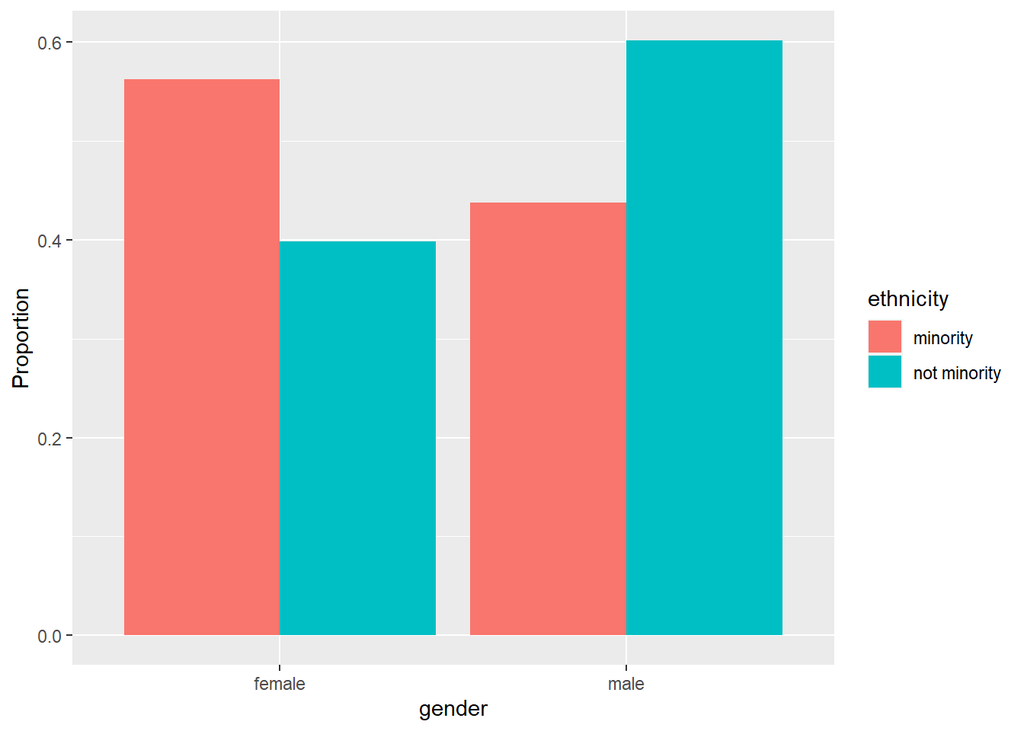

```r
ggplot(evals, aes(x= gender,  y = ..prop.., group=ethnicity, fill=ethnicity)) +
    geom_bar(position="dodge", stat="count") +
    labs(y = "Proportion")
```

Now we shall fit a logistic regression model to determine whether the gender of a teaching instructor can be predicted from their ethnicity.

## Log-odds

logistic regression model:

```r
model.ethnic <- glm(gender ~ ethnicity, data = evals.ethnic, family = binomial(link = "logit"))

model.ethnic %>%
  summary()
```

```
##
## Call:
## glm(formula = gender ~ ethnicity, family = binomial(link = "logit"),
##     data = evals.ethnic)
##
## Deviance Residuals:
##    Min      1Q  Median      3Q     Max
## -1.357  -1.357   1.008   1.008   1.286
##
## Coefficients:
##                       Estimate Std. Error z value Pr(>|z|)
## (Intercept)            -0.2513     0.2520  -0.997   0.3186
## ethnicitynot minority   0.6630     0.2719   2.438   0.0148 *
## ---
## Signif. codes:  0 '***' 0.001 '**' 0.01 '*' 0.05 '.' 0.1 ' ' 1
##
## (Dispersion parameter for binomial family taken to be 1)
##
##     Null deviance: 630.30  on 462  degrees of freedom
## Residual deviance: 624.29  on 461  degrees of freedom
## AIC: 628.29
##
## Number of Fisher Scoring iterations: 4
```

```r
levels(evals.ethnic$ethnicity)
```

```
## [1] "minority"     "not minority"
```

95% confidence interval for these log-odds

```r
confint(model.ethnic) %>%
  kable()
```

|  | 2.5 % | 97.5 % |
| --- | --- | --- |
| (Intercept) | -0.7528361 | 0.2399681 |
| ethnicitynot minority | 0.1326254 | 1.2026656 |

#or calculate the CI:

```r
mod.ethnic.coef.logodds <- model.ethnic %>%
                            summary() %>%
                            coef()
mod.ethnic.coef.logodds
```

```
##                         Estimate Std. Error    z value   Pr(>|z|)
## (Intercept)           -0.2513144  0.2519763 -0.9973732 0.31858339
## ethnicitynot minority  0.6630491  0.2719339  2.4382734 0.01475761
```

```r
ethnic.logodds.lower <- mod.ethnic.coef.logodds["ethnicitynot minority", "Estimate"] -
                        1.96 * mod.ethnic.coef.logodds["ethnicitynot minority", "Std. Error"]

ethnic.logodds.upper <- mod.ethnic.coef.logodds["ethnicitynot minority", "Estimate"] +
                        1.96 * mod.ethnic.coef.logodds["ethnicitynot minority", "Std. Error"]

ethnic.logodds.lower
```

```
## [1] 0.1300587
```

```r
ethnic.logodds.upper
```

```
## [1] 1.19604
```

Hence the point estimate for the log-odds is 0.66, which has a corresponding 95% confidence interval of (0.13, 1.2).

displayed graphically

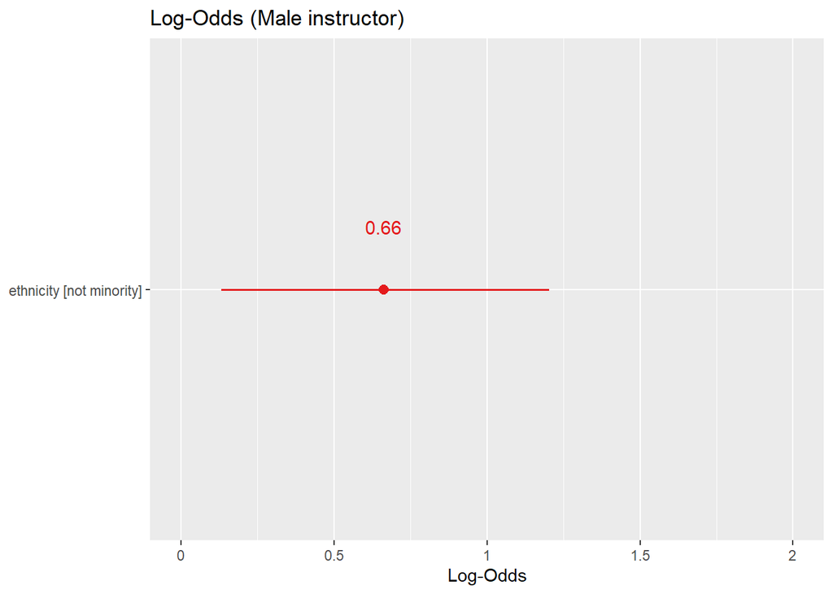

```r
plot_model(model.ethnic, show.values = TRUE, transform = NULL,
           title = "Log-Odds (Male instructor)", show.p = FALSE)
```

add the estimates of the log-odds to our data set:

```r
evals.ethnic <- evals.ethnic %>%
                  mutate(logodds.male = predict(model.ethnic))
evals.ethnic
```

| gender | ethnicity | logodds.male |
| --- | --- | --- |
| female | minority | -0.2513144 |
| female | minority | -0.2513144 |
| female | minority | -0.2513144 |
| female | minority | -0.2513144 |
| male | not minority | 0.4117347 |
| male | not minority | 0.4117347 |
| male | not minority | 0.4117347 |
| male | not minority | 0.4117347 |
| male | not minority | 0.4117347 |
| female | not minority | 0.4117347 |

[output cut: 453 more lines]

## Odds

```r
model.ethnic %>%
 coef() %>%
  exp()
```

```
##           (Intercept) ethnicitynot minority
##             0.7777778             1.9407008
```

```r
# the number of instructors in the minority
pmin <- evals.ethnic %>%
              filter(ethnicity == "minority") %>%
              summarize(n()) %>%
              pull()
pmin
```

```
## [1] 64
```

```r
# the number of male instructors in the minority
pmin.male <- evals.ethnic %>%
              filter(ethnicity == "minority", gender == "male") %>%
              summarize(n()) %>%
              pull()
pmin.male
```

```
## [1] 28
```

```r
# the proportion/probability of males in the minority
prob.min.male <- pmin.male / pmin
prob.min.male
```

```
## [1] 0.4375
```

```r
# the odds of an instructor being male given they are in the minority
odds.min.male <- prob.min.male / (1 - prob.min.male)
odds.min.male
```

```
## [1] 0.7777778
```

95% confidence interval for the odds

```r
ethnic.odds.lower <- exp(ethnic.logodds.lower)
ethnic.odds.lower
```

```
## [1] 1.138895
```

```r
ethnic.odds.upper <- exp(ethnic.logodds.upper)
ethnic.odds.upper
```

```
## [1] 3.306994
```

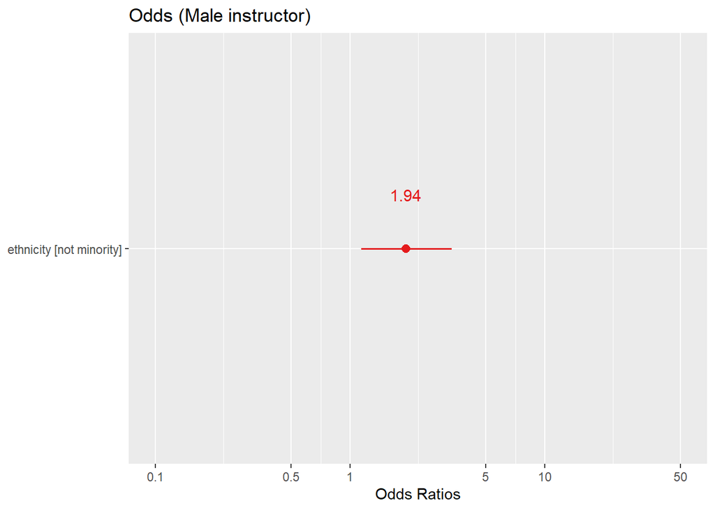

```r
plot_model(model.ethnic, show.values = TRUE,
           title = "Odds (Male instructor)", show.p = FALSE)
```

add the estimates of the odds:

```r
evals.ethnic <- evals.ethnic %>%
                  mutate(odds.male = exp(logodds.male))
evals.ethnic
```

| gender | ethnicity | logodds.male | odds.male |
| --- | --- | --- | --- |
| female | minority | -0.2513144 | 0.7777778 |
| female | minority | -0.2513144 | 0.7777778 |
| female | minority | -0.2513144 | 0.7777778 |
| female | minority | -0.2513144 | 0.7777778 |
| male | not minority | 0.4117347 | 1.5094340 |
| male | not minority | 0.4117347 | 1.5094340 |
| male | not minority | 0.4117347 | 1.5094340 |
| male | not minority | 0.4117347 | 1.5094340 |
| male | not minority | 0.4117347 | 1.5094340 |
| female | not minority | 0.4117347 | 1.5094340 |

[output cut: 453 more lines]

## Probabilities

The probabilities of an instructor being male given they are in the minority and not minority groups are:

```r
plogis(mod.ethnic.coef.logodds["(Intercept)", "Estimate"])
```

```
## [1] 0.4375
```

```r
plogis(mod.ethnic.coef.logodds["(Intercept)", "Estimate"] +
         mod.ethnic.coef.logodds["ethnicitynot minority", "Estimate"])
```

```
## [1] 0.6015038
```

add the probabilities to our data:

```r
evals.ethnic <- evals.ethnic %>%
                  mutate(probs.male = fitted(model.ethnic))
evals.ethnic
```

| gender | ethnicity | logodds.male | odds.male | probs.male |
| --- | --- | --- | --- | --- |
| female | minority | -0.2513144 | 0.7777778 | 0.4375000 |
| female | minority | -0.2513144 | 0.7777778 | 0.4375000 |
| female | minority | -0.2513144 | 0.7777778 | 0.4375000 |
| female | minority | -0.2513144 | 0.7777778 | 0.4375000 |
| male | not minority | 0.4117347 | 1.5094340 | 0.6015038 |
| male | not minority | 0.4117347 | 1.5094340 | 0.6015038 |
| male | not minority | 0.4117347 | 1.5094340 | 0.6015038 |
| male | not minority | 0.4117347 | 1.5094340 | 0.6015038 |
| male | not minority | 0.4117347 | 1.5094340 | 0.6015038 |
| female | not minority | 0.4117347 | 1.5094340 | 0.6015038 |

[output cut: 453 more lines]

produce the estimated probabilities:

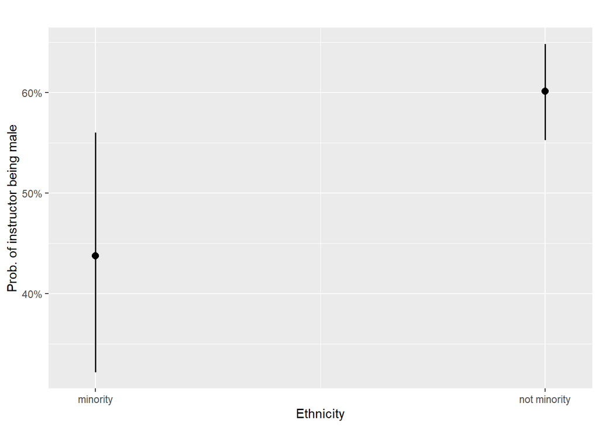

```r
plot_model(model.ethnic, type = "pred", title = "",
            axis.title = c("Ethnicity", "Prob. of instructor being male"))
```